# L01 Introduction

Data Visualization (STAT 302)

Noah Holubow

## Overview

The goals of this lab are to (1) ensure that the major software for this course is properly installed and functional, (2) develop and follow a proper workflow, and (3) work together to construct a few plots to explore a dataset using `ggplot2` — demonstration of the utility and power of `ggplot2`.

**Don’t worry if you cannot do everything here by yourself.** You are just getting started and the learning curve is steep, but remember that the instructional team and your classmates will be there to provide support. Persevere and put forth an honest effort and this course will payoff.

```r
# Load package(s) - We will do this together
library(tidyverse)
library(naniar)
library(skimr)
```

## Dataset

We’ll be using data from the [**lego** package](https://github.com/seankross/lego) which is already in the `/data` subdirectory, along with many other processed datasets, as part of the zipped folder for this lab.

## Tasks

Complete the following tasks. For many of these you’ll need to simply indicate that you have completed the task. In others, you’ll need to run some R code and/or supply a sentence or two.

### Task 1

Download and install [R Software](https://cran.rstudio.com/). **Answer: completed**

### Task 3

Install the following packages:

- `tidyverse`
- `ggstance`
- `skimr`

**Answer: completed**

### Task 4

1. Download `data_vis_labs.zip` from Canvas.
2. Unzip the file and place the unzipped `data_vis_labs` directory where you would like to keep all of your lab work for this course.
3. Open RStudio and create a project folder for this *exsisting directory*.
4. Appropriately rename `template_L01.Rmd` for submission (e.g. *Kuper_Arend_L01.Rmd*).
5. Compile the *_L01.Rmd file with `Cmd/Ctrl + Shift + K`.

**Answer: completed**

### Task 5

Optional: It is always handy to have a versatile text editor and I would suggest downloading [Sublime Text](https://www.sublimetext.com/). It is free to use.

**Answer: completed**

## Exercise 1

Let’s look at some interesting patterns in the history of LEGO! We’ll be using data from the [**lego** package](https://github.com/seankross/lego) located `data/legosets.rda`. We will work through this exercise together in class.

```r
# loading data
load("data/legosets.rda")
```

### Inspect the data

The **lego** package provides a helpful dataset some interesting variables. Let’s take a quick look at the data.

```r
# skimming the data without charts
legosets %>%
  skim_without_charts()
```

Data summary

| Name | Piped data |
| --- | --- |
| Number of rows | 6172 |
| Number of columns | 14 |
| _______________________ |  |
| Column type frequency: |  |
| character | 7 |
| numeric | 7 |
| ________________________ |  |
| Group variables | None |

**Variable type: character**

| skim_variable | n_missing | complete_rate | min | max | empty | n_unique | whitespace |
| --- | --- | --- | --- | --- | --- | --- | --- |
| Item_Number | 0 | 1 | 1 | 13 | 0 | 5854 | 0 |
| Name | 0 | 1 | 2 | 73 | 0 | 5519 | 0 |
| Theme | 0 | 1 | 4 | 28 | 0 | 115 | 0 |
| Subtheme | 0 | 1 | 0 | 32 | 2206 | 358 | 0 |
| Image_URL | 0 | 1 | 46 | 58 | 0 | 6172 | 0 |
| Packaging | 0 | 1 | 3 | 21 | 0 | 14 | 0 |
| Availability | 0 | 1 | 6 | 21 | 0 | 8 | 0 |

**Variable type: numeric**

| skim_variable | n_missing | complete_rate | mean | sd | p0 | p25 | p50 | p75 | p100 |
| --- | --- | --- | --- | --- | --- | --- | --- | --- | --- |
| Year | 0 | 1.00 | 2004.71 | 8.91 | 1971.00 | 2000.00 | 2006.00 | 2012.00 | 2015.00 |
| Pieces | 112 | 0.98 | 215.17 | 356.20 | 0.00 | 30.00 | 82.00 | 256.25 | 5922.00 |
| Minifigures | 2672 | 0.57 | 2.85 | 2.72 | 1.00 | 1.00 | 2.00 | 4.00 | 32.00 |
| GBP_MSRP | 1980 | 0.68 | 23.45 | 31.93 | 0.00 | 5.99 | 12.99 | 29.99 | 509.99 |
| USD_MSRP | 355 | 0.94 | 27.90 | 39.32 | 0.00 | 6.00 | 14.99 | 34.99 | 789.99 |
| CAD_MSRP | 4190 | 0.32 | 46.34 | 58.46 | 2.99 | 12.99 | 24.99 | 54.99 | 789.99 |
| EUR_MSRP | 4399 | 0.29 | 35.98 | 46.61 | 0.00 | 9.99 | 19.99 | 39.99 | 699.99 |

```r
# looking at missingness
miss_var_summary(legosets)
```

```
## # A tibble: 14 x 3
##    variable     n_miss pct_miss
##    <chr>         <int>    <dbl>
##  1 EUR_MSRP       4399    71.3
##  2 CAD_MSRP       4190    67.9
##  3 Minifigures    2672    43.3
##  4 GBP_MSRP       1980    32.1
##  5 USD_MSRP        355     5.75
##  6 Pieces          112     1.81
##  7 Item_Number       0     0
##  8 Name              0     0
##  9 Year              0     0
## 10 Theme             0     0
## 11 Subtheme          0     0
## 12 Image_URL         0     0
## 13 Packaging         0     0
## 14 Availability      0     0
```

### Price per year

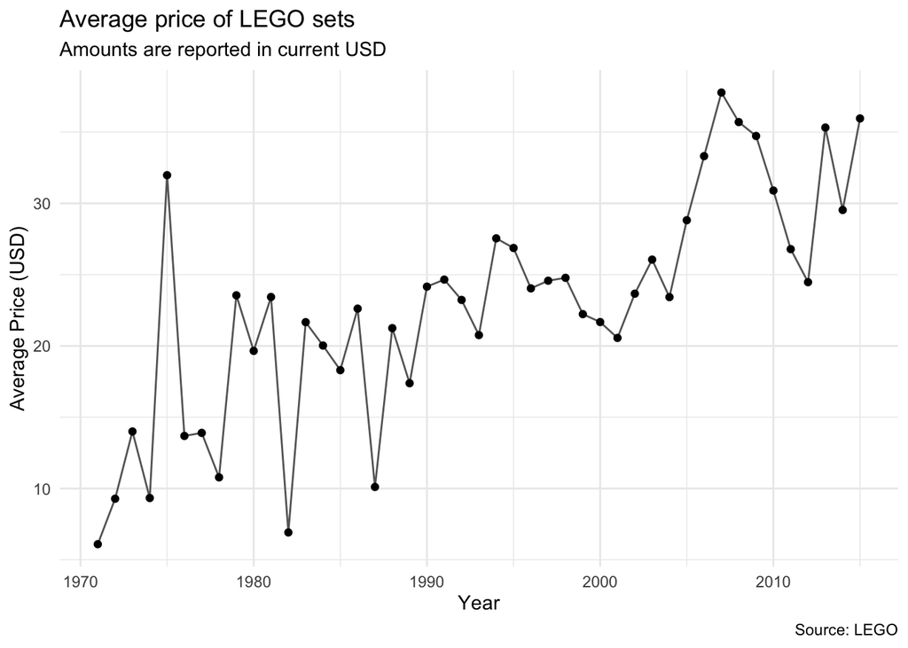

```r
# creating line plot
legosets %>%
  filter(!is.na(USD_MSRP)) %>% # filtering out missing values
  group_by(Year) %>% # grouping products by year
  summarise(avg = mean(USD_MSRP)) %>% # calculating average price for all products per year
  ggplot(aes(x = Year, y = avg)) + # setting up basic plot
  geom_line(color = "#666666", size = 0.5) + # creating line plot
  geom_point() + # adding points for each year
  labs(x = "Year", y = "Average Price (USD)", # x, y labels
       title = "Average price of LEGO sets", # title
       subtitle = "Amounts are reported in current USD", # subtitle
       caption = "Source: LEGO") + # caption
  theme_minimal() # white/gray theme
```

**Answer: we see that prices have been increasing on average over time. However, it is important to note that these are current prices and are not adjusted for inflation.**

### Pieces per year

Next, let’s look at how the number of pieces per set has changed over time. Because Duplo sets are much smaller (since they’re designed for toddlers), we’ll make a special indicator variable for them.

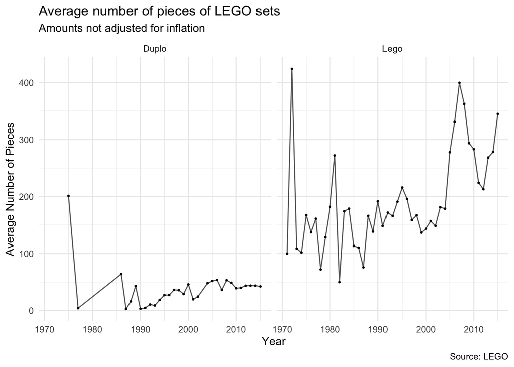

```r
# creating line plot
legosets %>%
  filter(!is.na(Pieces), Pieces > 0) %>% # filtering out missing values
  mutate(Duplo = if_else(Theme == "Duplo", "Duplo", "Lego")) %>% # set Duplo variable to Duplo or Lego
  group_by(Year, Duplo) %>% # grouping products by year
  summarise(avg = mean(Pieces),
            num_sets = n()) %>% # calculating average number of pieces for all products per year
  ggplot(aes(x = Year, y = avg)) + # setting up basic plot
  geom_line(color = "#666666", size = 0.5) + # creating line plot
  geom_point(size = 0.5) + # adding points for each year
  labs(x = "Year", y = "Average Number of Pieces",
       title = "Average number of pieces of LEGO sets",
       subtitle = "Amounts not adjusted for inflation",
       caption = "Source: LEGO") + # x, y labels
  facet_wrap( ~ Duplo) +
  theme_minimal()
```

**Answer: we see that pieces for Legos have gone up substantially. However, for Duplo, the number of pieces decreased at the beginning and then slightly increased but seems to have leveled out.**

### LEGO set themes

In the 1990s, [LEGO began partnering with famous brands and franchises](https://www.cnbc.com/2018/04/27/lego-marketing-strategy-made-it-world-favorite-toy-brand.html) to boost its own sales. First, let’s see how many different “themes” LEGO now offers:

**Answer: we see that LEGO offers 115 distinct themes.**

```r
# counting distinct models
nrow(legosets %>%
  distinct(Theme)) # number of distinct themes
```

```
## [1] 115
```

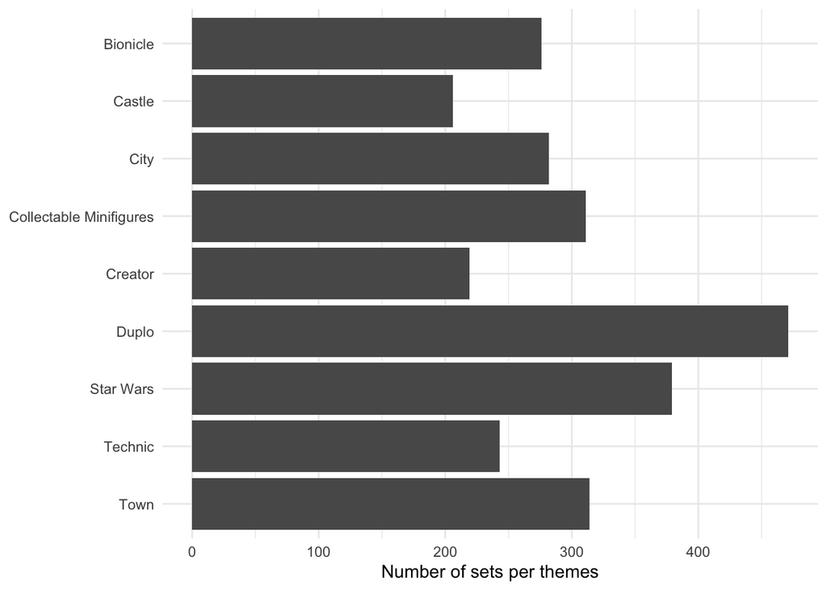

```r
# theme counts
theme_counts <- legosets %>%
  count(Theme, sort = TRUE) # counting number of products per theme

# plotting theme counts
theme_counts %>%
  filter(n > 200) %>% # only themes with >200 counts
  ggplot(mapping = aes(y = fct_rev(Theme), x = n)) +
  geom_col() +
  labs(
    x = "Number of sets per themes",
    y = NULL) +
  theme_minimal()
```